# Heart Disease Prediction

Aadesh Anil Nikam

2026-05-06

```r
pkgs <- c(
  "tidyverse", "tableone", "corrplot", "caret",
  "pROC", "glmnet", "randomForest",
  "ResourceSelection", "dcurves", "gridExtra", "broom"
)
new_pkgs <- pkgs[!pkgs %in% installed.packages()[, "Package"]]
if (length(new_pkgs)) install.packages(new_pkgs, dependencies = TRUE)
invisible(lapply(pkgs, library, character.only = TRUE))

set.seed(42)
```

## 0.1 Load Data

```r
heart_raw <- read.csv("heart.csv", stringsAsFactors = FALSE)
cat("Raw dimensions:", nrow(heart_raw), "rows x", ncol(heart_raw), "cols\n")
```

```
## Raw dimensions: 1025 rows x 14 cols
```

## 0.2 Duplicate Rows

```r
n_dup <- sum(duplicated(heart_raw))
cat("Exact duplicate rows found:", n_dup, "\n")
```

```
## Exact duplicate rows found: 723
```

```r
cat("These are removed to avoid artificially inflated test-set performance.\n")
```

```
## These are removed to avoid artificially inflated test-set performance.
```

```r
heart <- distinct(heart_raw)
cat("Rows after deduplication:", nrow(heart), "\n")
```

```
## Rows after deduplication: 302
```

## 0.3 Missing Values

```r
cat("Missing values per variable:\n")
```

```
## Missing values per variable:
```

```r
print(colSums(is.na(heart)))
```

```
##      age      sex       cp trestbps     chol      fbs  restecg  thalach
##        0        0        0        0        0        0        0        0
##    exang  oldpeak    slope       ca     thal   target
##        0        0        0        0        0        0
```

```r
cat("Total missing:", sum(is.na(heart)), "\n")
```

```
## Total missing: 0
```

## 0.4 Recode Variables

```r
heart <- heart %>%
  mutate(
    target  = factor(target,  levels = c(0, 1),
                     labels = c("No_HD", "HD")),
    sex     = factor(sex,     levels = c(0, 1),
                     labels = c("Female", "Male")),
    cp      = factor(cp,      levels = 0:3,
                     labels = c("Typical", "Atypical", "NonAnginal", "Asympt")),
    fbs     = factor(fbs,     levels = c(0, 1),
                     labels = c("Normal", "High")),
    restecg = factor(restecg, levels = 0:2,
                     labels = c("Normal", "ST_T", "LV_Hypertrophy")),
    exang   = factor(exang,   levels = c(0, 1),
                     labels = c("No", "Yes")),
    slope   = factor(slope,   levels = 0:2,
                     labels = c("Down", "Flat", "Up")),
    ca      = factor(ca),
    thal    = factor(thal,    levels = 0:3,
                     labels = c("Unknown", "Normal", "Fixed", "Reversible"))
  )
```

## 0.5 Outcome Distribution

```r
cat("Outcome distribution (deduplicated sample):\n")
```

```
## Outcome distribution (deduplicated sample):
```

```r
print(table(heart$target))
```

```
##
## No_HD    HD
##   138   164
```

```r
print(round(prop.table(table(heart$target)), 3))
```

```
##
## No_HD    HD
## 0.457 0.543
```

## 0.6 Data Size (n × p)

```r
cat("Observations (n):", nrow(heart), "\n")
```

```
## Observations (n): 302
```

```r
cat("Predictors (p):  ", ncol(heart) - 1, "\n")
```

```
## Predictors (p):   13
```

```r
cat("HD cases:        ", sum(heart$target == "HD"), "\n")
```

```
## HD cases:         164
```

```r
cat("Non-HD controls: ", sum(heart$target == "No_HD"), "\n")
```

```
## Non-HD controls:  138
```

# 1 Exploratory Data Analysis

```r
cat_vars  <- c("sex", "cp", "fbs", "restecg", "exang", "slope", "ca", "thal")
cont_vars <- c("age", "trestbps", "chol", "thalach", "oldpeak")
```

## 1.1 Table 1 — Descriptive Statistics by Outcome

```r
tab1 <- CreateTableOne(
  vars       = c(cont_vars, cat_vars),
  strata     = "target",
  data       = heart,
  factorVars = cat_vars
)
print(tab1, showAllLevels = TRUE, quote = FALSE, noSpaces = TRUE)
```

```
##                       Stratified by target
##                        level          No_HD          HD             p      test
##   n                                   138            164
##   age (mean (SD))                     56.60 (7.96)   52.59 (9.51)   <0.001
##   trestbps (mean (SD))                134.40 (18.73) 129.25 (16.20) 0.011
##   chol (mean (SD))                    251.09 (49.45) 242.64 (53.46) 0.158
##   thalach (mean (SD))                 139.10 (22.60) 158.38 (19.20) <0.001
##   oldpeak (mean (SD))                 1.59 (1.30)    0.59 (0.78)    <0.001
##   sex (%)              Female         24 (17.4)      72 (43.9)      <0.001
##                        Male           114 (82.6)     92 (56.1)
##   cp (%)               Typical        104 (75.4)     39 (23.8)      <0.001
##                        Atypical       9 (6.5)        41 (25.0)
##                        NonAnginal     18 (13.0)      68 (41.5)
##                        Asympt         7 (5.1)        16 (9.8)
##   fbs (%)              Normal         116 (84.1)     141 (86.0)     0.761
##                        High           22 (15.9)      23 (14.0)
##   restecg (%)          Normal         79 (57.2)      68 (41.5)      0.008
##                        ST_T           56 (40.6)      95 (57.9)
##                        LV_Hypertrophy 3 (2.2)        1 (0.6)
##   exang (%)            No             62 (44.9)      141 (86.0)     <0.001
##                        Yes            76 (55.1)      23 (14.0)
##   slope (%)            Down           12 (8.7)       9 (5.5)        <0.001
##                        Flat           91 (65.9)      49 (29.9)
##                        Up             35 (25.4)      106 (64.6)
##   ca (%)               0              45 (32.6)      130 (79.3)     <0.001
##                        1              44 (31.9)      21 (12.8)
##                        2              31 (22.5)      7 (4.3)
##                        3              17 (12.3)      3 (1.8)
##                        4              1 (0.7)        3 (1.8)
##   thal (%)             Unknown        1 (0.7)        1 (0.6)        <0.001
##                        Normal         12 (8.7)       6 (3.7)
##                        Fixed          36 (26.1)      129 (78.7)
##                        Reversible     89 (64.5)      28 (17.1)
```

## 1.2 Continuous Predictors by Outcome

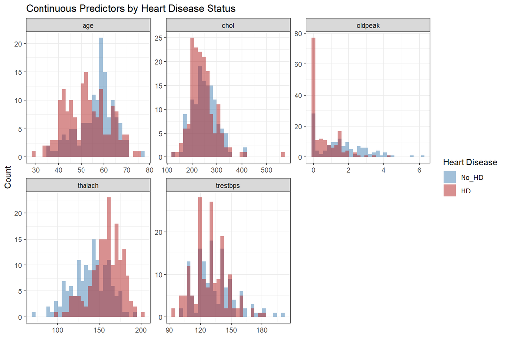

```r
cont_long <- heart %>%
  select(target, all_of(cont_vars)) %>%
  pivot_longer(-target, names_to = "variable", values_to = "value")

ggplot(cont_long, aes(x = value, fill = target)) +
  geom_histogram(alpha = 0.5, bins = 30, position = "identity") +
  facet_wrap(~variable, scales = "free") +
  scale_fill_manual(values = c("steelblue", "firebrick"),
                    name = "Heart Disease") +
  labs(title = "Continuous Predictors by Heart Disease Status",
       x = NULL, y = "Count") +
  theme_bw(base_size = 11)
```

## 1.3 Categorical Predictors by Outcome

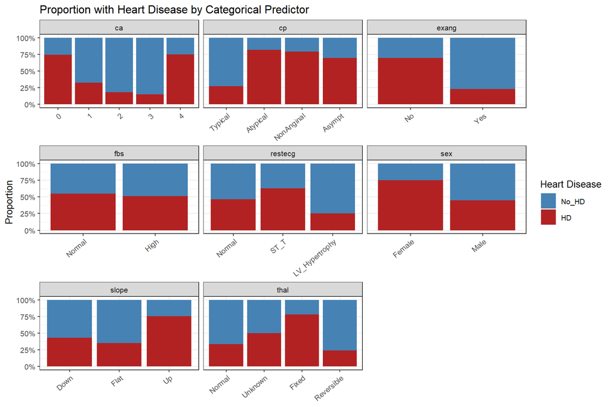

```r
cat_long <- heart %>%
  select(target, all_of(cat_vars)) %>%
  pivot_longer(-target, names_to = "variable", values_to = "level")

ggplot(cat_long, aes(x = level, fill = target)) +
  geom_bar(position = "fill") +
  facet_wrap(~variable, scales = "free_x") +
  scale_fill_manual(values = c("steelblue", "firebrick"),
                    name = "Heart Disease") +
  scale_y_continuous(labels = scales::percent) +
  labs(title = "Proportion with Heart Disease by Categorical Predictor",
       x = NULL, y = "Proportion") +
  theme_bw(base_size = 10) +
  theme(axis.text.x = element_text(angle = 40, hjust = 1))
```

## 1.4 Correlation Matrix (Continuous Variables Only)

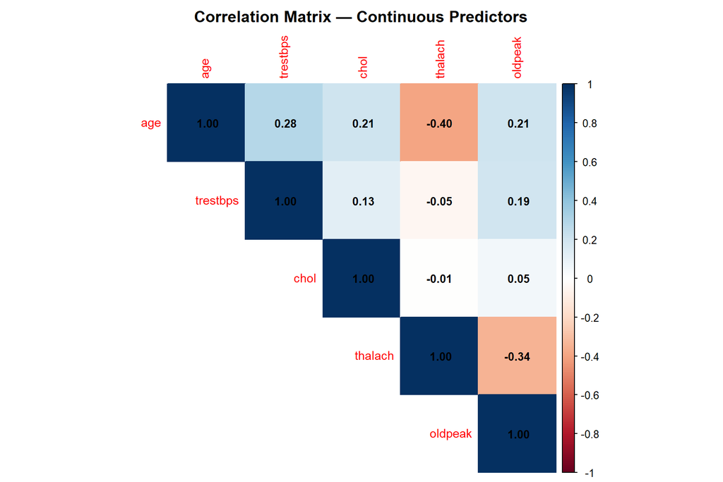

```r
corrplot(
  cor(heart %>% select(all_of(cont_vars))),
  method = "color", type = "upper",
  addCoef.col = "black", tl.cex = 0.9, number.cex = 0.85,
  title = "Correlation Matrix — Continuous Predictors",
  mar   = c(0, 0, 2, 0)
)
```

# 2 Train / Test Split

```r
train_idx <- createDataPartition(heart$target, p = 0.70, list = FALSE)
train_df  <- heart[ train_idx, ]
test_df   <- heart[-train_idx, ]

cat("Training set:", nrow(train_df), "rows |",
    sum(train_df$target == "HD"), "HD cases\n")
```

```
## Training set: 212 rows | 115 HD cases
```

```r
cat("Test set:    ", nrow(test_df),  "rows |",
    sum(test_df$target  == "HD"), "HD cases\n")
```

```
## Test set:     90 rows | 49 HD cases
```

```r
# Numeric outcome for test set (used in calibration / DCA)
y_test <- as.numeric(test_df$target == "HD")
```

# 3 Methods & Results

## 3.1 Helper Functions

```r
# Predicted class from probabilities
make_class <- function(probs, thr = 0.5) {
  factor(ifelse(probs > thr, "HD", "No_HD"), levels = c("No_HD", "HD"))
}


# Performance metrics
get_metrics <- function(probs, actual, model_name) {
  cm      <- confusionMatrix(make_class(probs), actual, positive = "HD")
  roc_obj <- roc(actual, probs, levels = c("No_HD", "HD"), quiet = TRUE)
  brier   <- mean((probs - as.numeric(actual == "HD"))^2)
  data.frame(
    Model       = model_name,
    AUC         = round(auc(roc_obj), 4),
    Accuracy    = round(cm$overall["Accuracy"],       4),
    Sensitivity = round(cm$byClass["Sensitivity"],    4),
    Specificity = round(cm$byClass["Specificity"],    4),
    PPV         = round(cm$byClass["Pos Pred Value"], 4),
    NPV         = round(cm$byClass["Neg Pred Value"], 4),
    Brier       = round(brier, 4),
    row.names   = NULL
  )
}
```

## 3.2 Model 1 — Logistic Regression

Logistic regression was fitted using all 13 predictors. It serves as the interpretable baseline model, providing odds ratios that have direct clinical meaning.

```r
lr_fit <- glm(target ~ ., data = train_df, family = binomial)
summary(lr_fit)
```

```
##
## Call:
## glm(formula = target ~ ., family = binomial, data = train_df)
##
## Coefficients:
##                         Estimate Std. Error z value Pr(>|z|)
## (Intercept)            1.259e+01  2.400e+03   0.005 0.995813
## age                    5.255e-02  3.595e-02   1.462 0.143844
## sexMale               -1.042e+00  7.069e-01  -1.474 0.140479
## cpAtypical             8.492e-01  7.046e-01   1.205 0.228166
## cpNonAnginal           1.797e+00  6.622e-01   2.713 0.006664 **
## cpAsympt               2.801e+00  1.012e+00   2.768 0.005632 **
## trestbps              -3.771e-02  1.540e-02  -2.448 0.014355 *
## chol                  -9.324e-04  5.214e-03  -0.179 0.858066
## fbsHigh                5.472e-01  7.400e-01   0.739 0.459671
## restecgST_T            5.455e-01  4.921e-01   1.109 0.267576
## restecgLV_Hypertrophy -1.408e+01  1.236e+03  -0.011 0.990907
## thalach                2.857e-02  1.498e-02   1.907 0.056467 .
## exangYes              -9.821e-01  5.450e-01  -1.802 0.071524 .
## oldpeak               -2.056e-01  2.916e-01  -0.705 0.480905
## slopeFlat             -2.998e-01  1.050e+00  -0.286 0.775212
## slopeUp                1.136e+00  1.128e+00   1.007 0.313968
## ca1                   -2.209e+00  6.729e-01  -3.283 0.001028 **
## ca2                   -3.511e+00  1.036e+00  -3.390 0.000699 ***
## ca3                   -1.865e+00  1.050e+00  -1.777 0.075650 .
## ca4                    1.565e+00  1.940e+00   0.807 0.419918
## thalNormal            -1.256e+01  2.400e+03  -0.005 0.995823
## thalFixed             -1.295e+01  2.400e+03  -0.005 0.995693
## thalReversible        -1.492e+01  2.400e+03  -0.006 0.995038
## ---
## Signif. codes:  0 '***' 0.001 '**' 0.01 '*' 0.05 '.' 0.1 ' ' 1
##
## (Dispersion parameter for binomial family taken to be 1)
##
##     Null deviance: 292.36  on 211  degrees of freedom
## Residual deviance: 121.29  on 189  degrees of freedom
## AIC: 167.29
##
## Number of Fisher Scoring iterations: 15
```

### 3.2.1 Odds Ratios

```r
round(exp(cbind(OR = coef(lr_fit), confint(lr_fit))), 3)
```

```
##                               OR 2.5 %        97.5 %
## (Intercept)           293848.443 0.000            NA
## age                        1.054 0.984  1.134000e+00
## sexMale                    0.353 0.084  1.382000e+00
## cpAtypical                 2.338 0.612  1.013000e+01
## cpNonAnginal               6.029 1.744  2.406700e+01
## cpAsympt                  16.463 2.529  1.425460e+02
## trestbps                   0.963 0.933  9.920000e-01
## chol                       0.999 0.989  1.010000e+00
## fbsHigh                    1.728 0.416  7.732000e+00
## restecgST_T                1.726 0.659  4.611000e+00
## restecgLV_Hypertrophy      0.000    NA  8.976769e+61
## thalach                    1.029 1.000  1.062000e+00
## exangYes                   0.375 0.126  1.086000e+00
## oldpeak                    0.814 0.451  1.430000e+00
## slopeFlat                  0.741 0.089  5.988000e+00
## slopeUp                    3.115 0.315  2.943100e+01
## ca1                        0.110 0.027  3.920000e-01
## ca2                        0.030 0.003  2.070000e-01
## ca3                        0.155 0.016  1.074000e+00
## ca4                        4.781 0.108  2.835830e+02
## thalNormal                 0.000    NA 1.532494e+204
## thalFixed                  0.000    NA 1.823627e+205
## thalReversible             0.000    NA 1.918219e+204
```

### 3.2.2 Coefficient Plot

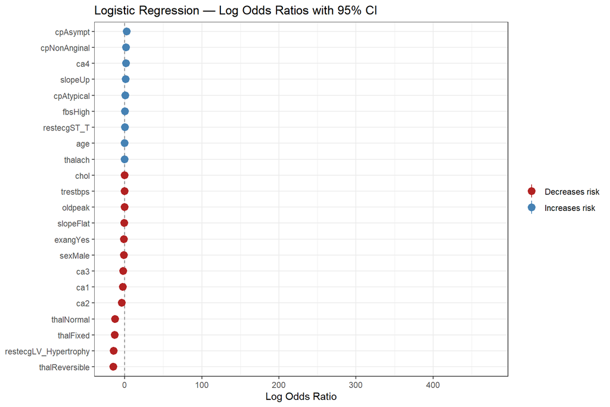

```r
coef_df <- tidy(lr_fit, conf.int = TRUE, exponentiate = FALSE) %>%
  filter(term != "(Intercept)") %>%
  mutate(direction = ifelse(estimate > 0, "Increases risk", "Decreases risk"))

ggplot(coef_df,
       aes(x = reorder(term, estimate), y = estimate,
           colour = direction, ymin = conf.low, ymax = conf.high)) +
  geom_hline(yintercept = 0, linetype = "dashed", colour = "grey50") +
  geom_pointrange(size = 0.7) +
  coord_flip() +
  scale_colour_manual(values = c("firebrick", "steelblue"), name = NULL) +
  labs(title = "Logistic Regression — Log Odds Ratios with 95% CI",
       x = NULL, y = "Log Odds Ratio") +
  theme_bw(base_size = 11)
```

```r
pred_lr <- predict(lr_fit, newdata = test_df, type = "response")
roc_lr  <- roc(test_df$target, pred_lr,
               levels = c("No_HD", "HD"), quiet = TRUE)
cat("Logistic Regression AUC:", round(auc(roc_lr), 4), "\n")
```

```
## Logistic Regression AUC: 0.8691
```

## 3.3 Model 2 — LASSO Logistic Regression

LASSO applies an L1 penalty to shrink unimportant coefficients to zero, performing automatic variable selection. The penalty parameter lambda was chosen by 10-fold cross-validation maximising AUC.

```r
dummies <- dummyVars(target ~ ., data = train_df, fullRank = TRUE)
X_train <- predict(dummies, newdata = train_df)
X_test  <- predict(dummies, newdata = test_df)

cv_lasso <- cv.glmnet(
  X_train,
  as.numeric(train_df$target == "HD"),
  family       = "binomial",
  alpha        = 1,
  nfolds       = 10,
  type.measure = "auc"
)
```

### 3.3.1 Cross-Validation Curve

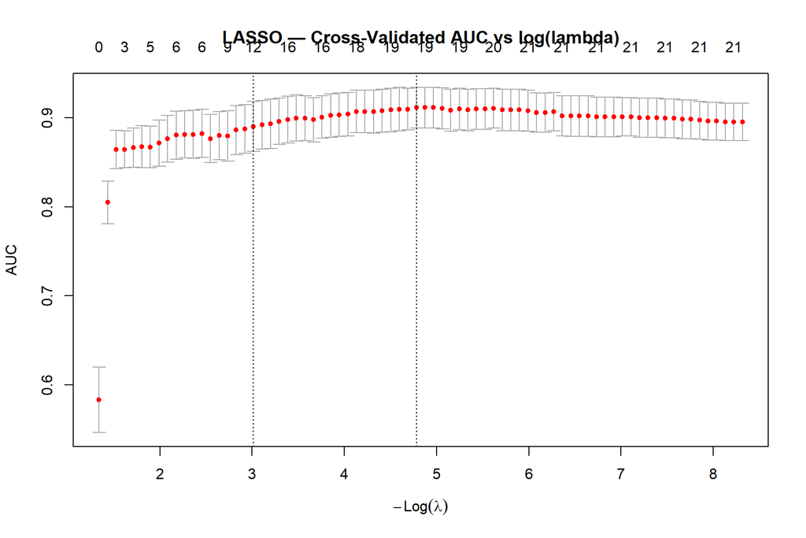

```r
plot(cv_lasso, main = "LASSO — Cross-Validated AUC vs log(lambda)")
```

```r
cat("Best lambda (1-SE rule):", round(cv_lasso$lambda.1se, 5), "\n")
```

```
## Best lambda (1-SE rule): 0.04908
```

### 3.3.2 Selected Predictors

```r
lasso_fit <- glmnet(
  X_train,
  as.numeric(train_df$target == "HD"),
  family = "binomial",
  alpha  = 1,
  lambda = cv_lasso$lambda.1se
)

lasso_coef <- coef(lasso_fit)
cat("Non-zero (selected) coefficients:\n")
```

```
## Non-zero (selected) coefficients:
```

```r
print(lasso_coef[lasso_coef[, 1] != 0, , drop = FALSE])
```

```
## 13 x 1 sparse Matrix of class "dgCMatrix"
##                          s0
## (Intercept)     -1.93963169
## cp.NonAnginal    0.28132291
## restecg.ST_T     0.03510918
## thalach          0.01836509
## exang.Yes       -0.76901041
## oldpeak         -0.19097631
## slope.Flat      -0.03958673
## slope.Up         0.34868620
## ca.1            -0.45361517
## ca.2            -0.61321278
## ca.3            -0.23561429
## thal.Fixed       0.40422713
## thal.Reversible -0.92715552
```

```r
pred_lasso <- as.vector(predict(lasso_fit, newx = X_test, type = "response"))
roc_lasso  <- roc(test_df$target, pred_lasso,
                  levels = c("No_HD", "HD"), quiet = TRUE)
cat("LASSO AUC:", round(auc(roc_lasso), 4), "\n")
```

```
## LASSO AUC: 0.8641
```

## 3.4 Model 3 — Random Forest

Random Forest grows 500 decision trees on bootstrap samples, each using a random subset of √p predictors at each split. It captures non-linear relationships and interactions without requiring variable transformations.

```r
rf_fit <- randomForest(
  target ~ .,
  data       = train_df,
  ntree      = 500,
  mtry       = floor(sqrt(ncol(train_df) - 1)),
  importance = TRUE
)
print(rf_fit)
```

```
##
## Call:
##  randomForest(formula = target ~ ., data = train_df, ntree = 500,      mtry = floor(sqrt(ncol(train_df) - 1)), importance = TRUE)
##                Type of random forest: classification
##                      Number of trees: 500
## No. of variables tried at each split: 3
##
##         OOB estimate of  error rate: 16.98%
## Confusion matrix:
##       No_HD HD class.error
## No_HD    79 18   0.1855670
## HD       18 97   0.1565217
```

### 3.4.1 Variable Importance

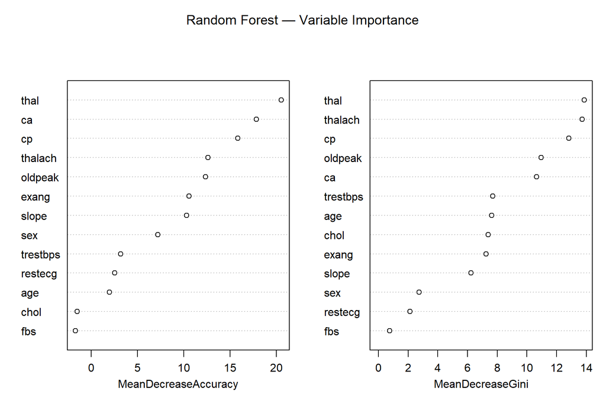

```r
varImpPlot(rf_fit, main = "Random Forest — Variable Importance")
```

```r
pred_rf <- predict(rf_fit, newdata = test_df, type = "prob")[, "HD"]
roc_rf  <- roc(test_df$target, pred_rf,
               levels = c("No_HD", "HD"), quiet = TRUE)
cat("Random Forest AUC:", round(auc(roc_rf), 4), "\n")
```

```
## Random Forest AUC: 0.9084
```

# 4 Model Evaluation

## 4.1 ROC Curves & AUC

> AUC and ROC curves are **fully valid** in a case-control dataset because they measure discrimination — the ability to rank cases above controls — and are not affected by the case-control sampling fraction.

### 4.1.1 Individual ROC Curves

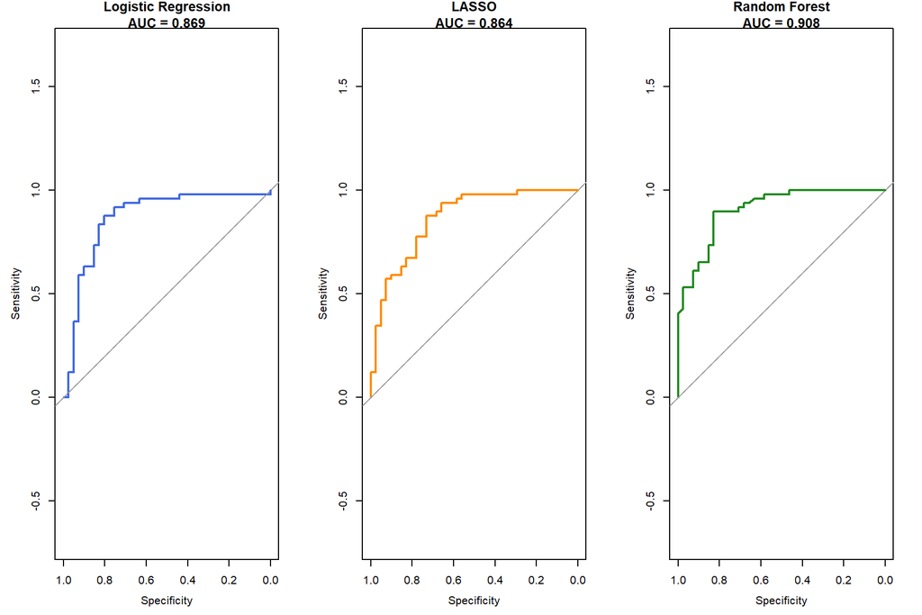

```r
par(mfrow = c(1, 3))

plot(roc_lr,    col = "royalblue",   lwd = 2,
     main = paste0("Logistic Regression\nAUC = ", round(auc(roc_lr), 3)))
abline(a = 1, b = -1, lty = 2, col = "grey60")

plot(roc_lasso, col = "darkorange",  lwd = 2,
     main = paste0("LASSO\nAUC = ", round(auc(roc_lasso), 3)))
abline(a = 1, b = -1, lty = 2, col = "grey60")

plot(roc_rf,    col = "forestgreen", lwd = 2,
     main = paste0("Random Forest\nAUC = ", round(auc(roc_rf), 3)))
abline(a = 1, b = -1, lty = 2, col = "grey60")
```

```r
par(mfrow = c(1, 1))
```

### 4.1.2 Combined ROC Overlay

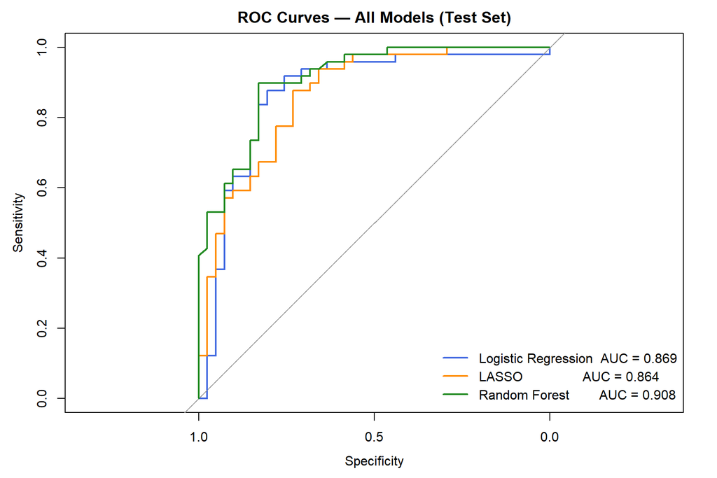

```r
plot(roc_lr,    col = "royalblue",   lwd = 2,
     main = "ROC Curves — All Models (Test Set)")
plot(roc_lasso, col = "darkorange",  lwd = 2, add = TRUE)
plot(roc_rf,    col = "forestgreen", lwd = 2, add = TRUE)
abline(a = 1, b = -1, lty = 2, col = "grey60")

legend("bottomright", bty = "n",
  legend = c(
    paste0("Logistic Regression  AUC = ", round(auc(roc_lr),    3)),
    paste0("LASSO                AUC = ", round(auc(roc_lasso),  3)),
    paste0("Random Forest        AUC = ", round(auc(roc_rf),     3))
  ),
  col = c("royalblue", "darkorange", "forestgreen"),
  lwd = 2
)
```

### 4.1.3 AUC Comparison Tests

```r
dl_lr_lasso <- roc.test(roc_lr,    roc_lasso, method = "delong")
dl_lr_rf    <- roc.test(roc_lr,    roc_rf,    method = "delong")
dl_lasso_rf <- roc.test(roc_lasso, roc_rf,    method = "delong")

cat(sprintf("LR vs LASSO:         p = %.4f\n", dl_lr_lasso$p.value))
```

```
## LR vs LASSO:         p = 0.8946
```

```r
cat(sprintf("LR vs Random Forest: p = %.4f\n", dl_lr_rf$p.value))
```

```
## LR vs Random Forest: p = 0.2815
```

```r
cat(sprintf("LASSO vs RF:         p = %.4f\n", dl_lasso_rf$p.value))
```

```
## LASSO vs RF:         p = 0.0396
```

## 4.2 Confusion Matrices

> A classification threshold of 0.5 is used here for illustration. Note that this threshold may not be optimal clinically — in a real application, the threshold would be chosen based on the relative costs of false positives and false negatives.

```r
cat("--- Logistic Regression ---\n")
```

```
## --- Logistic Regression ---
```

```r
print(confusionMatrix(make_class(pred_lr),    test_df$target, positive = "HD"))
```

```
## Confusion Matrix and Statistics
##
##           Reference
## Prediction No_HD HD
##      No_HD    29  4
##      HD       12 45
##
##                Accuracy : 0.8222
##                  95% CI : (0.7274, 0.8948)
##     No Information Rate : 0.5444
##     P-Value [Acc > NIR] : 2.84e-08
##
##                   Kappa : 0.6358
##
##  Mcnemar's Test P-Value : 0.08012
##
##             Sensitivity : 0.9184
##             Specificity : 0.7073
##          Pos Pred Value : 0.7895
##          Neg Pred Value : 0.8788
##              Prevalence : 0.5444
##          Detection Rate : 0.5000
##    Detection Prevalence : 0.6333
##       Balanced Accuracy : 0.8128
##
##        'Positive' Class : HD
##
```

```r
cat("--- LASSO ---\n")
```

```
## --- LASSO ---
```

```r
print(confusionMatrix(make_class(pred_lasso), test_df$target, positive = "HD"))
```

```
## Confusion Matrix and Statistics
##
##           Reference
## Prediction No_HD HD
##      No_HD    28  6
##      HD       13 43
##
##                Accuracy : 0.7889
##                  95% CI : (0.6901, 0.8679)
##     No Information Rate : 0.5444
##     P-Value [Acc > NIR] : 1.206e-06
##
##                   Kappa : 0.5684
##
##  Mcnemar's Test P-Value : 0.1687
##
##             Sensitivity : 0.8776
##             Specificity : 0.6829
##          Pos Pred Value : 0.7679
##          Neg Pred Value : 0.8235
##              Prevalence : 0.5444
##          Detection Rate : 0.4778
##    Detection Prevalence : 0.6222
##       Balanced Accuracy : 0.7802
##
##        'Positive' Class : HD
##
```

```r
cat("--- Random Forest ---\n")
```

```
## --- Random Forest ---
```

```r
print(confusionMatrix(make_class(pred_rf),    test_df$target, positive = "HD"))
```

```
## Confusion Matrix and Statistics
##
##           Reference
## Prediction No_HD HD
##      No_HD    32  5
##      HD        9 44
##
##                Accuracy : 0.8444
##                  95% CI : (0.7528, 0.9123)
##     No Information Rate : 0.5444
##     P-Value [Acc > NIR] : 1.629e-09
##
##                   Kappa : 0.6839
##
##  Mcnemar's Test P-Value : 0.4227
##
##             Sensitivity : 0.8980
##             Specificity : 0.7805
##          Pos Pred Value : 0.8302
##          Neg Pred Value : 0.8649
##              Prevalence : 0.5444
##          Detection Rate : 0.4889
##    Detection Prevalence : 0.5889
##       Balanced Accuracy : 0.8392
##
##        'Positive' Class : HD
##
```

## 4.3 Decision Curve Analysis

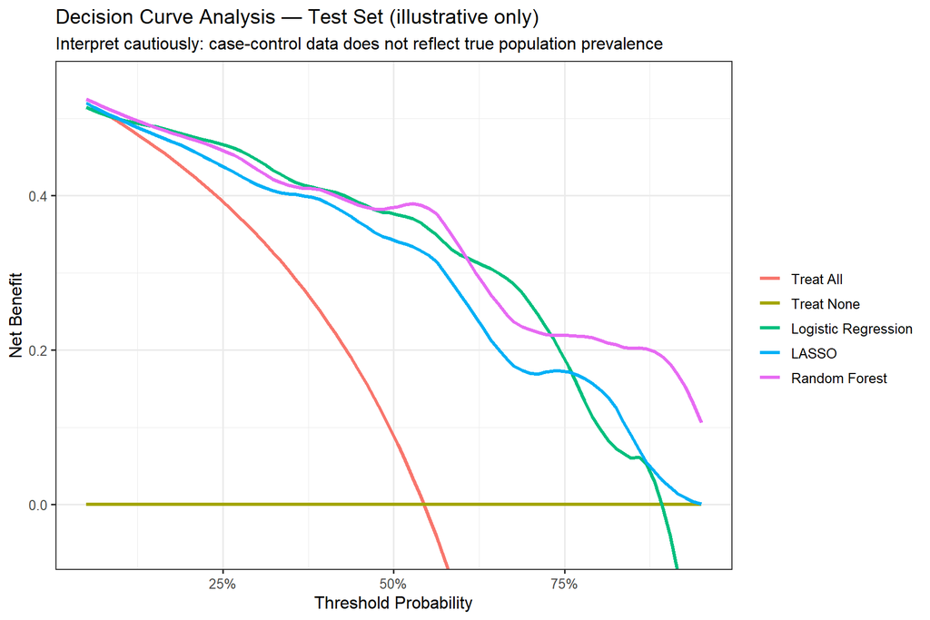

```r
dca_df <- data.frame(
  target = y_test,
  lr     = pred_lr,
  lasso  = pred_lasso,
  rf     = pred_rf
)

dca_res <- dca(
  target ~ lr + lasso + rf,
  data       = dca_df,
  thresholds = seq(0.05, 0.95, by = 0.01),
  label      = list(
    lr    = "Logistic Regression",
    lasso = "LASSO",
    rf    = "Random Forest"
  )
)

plot(dca_res, smooth = TRUE) +
  labs(
    title    = "Decision Curve Analysis — Test Set (illustrative only)",
    subtitle = "Interpret cautiously: case-control data does not reflect true population prevalence"
  ) +
  theme_bw(base_size = 12)
```

## Performance Summary Table

```r
perf_table <- bind_rows(
  get_metrics(pred_lr,    test_df$target, "Logistic Regression"),
  get_metrics(pred_lasso, test_df$target, "LASSO"),
  get_metrics(pred_rf,    test_df$target, "Random Forest")
) %>% arrange(desc(AUC))

knitr::kable(perf_table,
             caption = "Model Performance on Test Set (AUC, discrimination metrics fully valid; Brier score affected by case-control design)",
             digits  = 4,
             align   = "lrrrrrrr")
```

Model Performance on Test Set (AUC, discrimination metrics fully valid; Brier score affected by case-control design)

| Model | AUC | Accuracy | Sensitivity | Specificity | PPV | NPV | Brier |
| --- | --- | --- | --- | --- | --- | --- | --- |
| Random Forest | 0.9084 | 0.8444 | 0.8980 | 0.7805 | 0.8302 | 0.8649 | 0.1244 |
| Logistic Regression | 0.8691 | 0.8222 | 0.9184 | 0.7073 | 0.7895 | 0.8788 | 0.1340 |
| LASSO | 0.8641 | 0.7889 | 0.8776 | 0.6829 | 0.7679 | 0.8235 | 0.1505 |

# 5 Prevalence Adjustment for Predicted Probabilities

```r
pi_sample <- mean(y_test)
pi_pop    <- 0.07

offset <- qlogis(pi_pop) - qlogis(pi_sample)

pred_lr_recal <- plogis(qlogis(pred_lr) + offset)

cat("Sample event rate (case-control):  ", round(pi_sample, 3), "\n")
```

```
## Sample event rate (case-control):   0.544
```

```r
cat("Assumed population prevalence:     ", pi_pop, "\n")
```

```
## Assumed population prevalence:      0.07
```

```r
cat("Log-odds offset applied:           ", round(offset, 4), "\n\n")
```

```
## Log-odds offset applied:            -2.7649
```

```r
cat("Mean predicted prob — raw:         ", round(mean(pred_lr), 3), "\n")
```

```
## Mean predicted prob — raw:          0.577
```

```r
cat("Mean predicted prob — recalibrated:", round(mean(pred_lr_recal), 3), "\n")
```

```
## Mean predicted prob — recalibrated: 0.277
```